# Principal Components Analysis Notes

Shelby Blythe

11/8/2021

# Introduction:

For the demonstration of DESeq2, I used a built-in PCA plotting function (`DESeq2::plotPCA`). This is convenient for doing a quick PCA check on data after you’ve set up a DESeq object for analysis. This, however, is a very use-specific instance of doing PCA and is unnecessarily constrained. Here I have some notes on more general application of PCA to your data.

The alternative is to use the base-R PCA function `prcomp`. Below, I will set up the same data as for the DESeq2 demonstration and demonstrate this more general function.

This is important to cover since this isn’t necessarily just a thing you would want to do for DESeq analysis, but rather something that is useful for examining your data regardless of the downstream application.

# Data Setup:

(Copied from the DESeq2 demo, omitting some of the ‘checks’ and with noted changes. You can skip to the next section on PCA.)

```r
rm(list = ls()); gc()
```

```
##          used (Mb) gc trigger (Mb) limit (Mb) max used (Mb)
## Ncells 471092 25.2    1012535 54.1         NA   666882 35.7
## Vcells 884981  6.8    8388608 64.0      65536  1826466 14.0
```

```r
suppressPackageStartupMessages(
  {
  library(DESeq2)
  library(GenomicRanges)
  library(tidyverse)
  library(ggthemes)
    }
)

# Filepath to ATAC peaks
peakfile = "~/Dropbox/Blythe Lab/Patternless Paper/Patternless_ATAC/All_Samples_shortreads_q1e-5_MACS2_peaks.narrowPeak.GR"

# Filepath to ChIP peaks
peakfile2 = "~/Dropbox/Blythe Lab/Patternless Paper/Patternless_ATAC/opa.ChIP.peaks_IDR_filtered.GR"

# Filepaths to ATAC datasets: grouped by sample type, Genomic Ranges corresponding to short "open" ATAC-seq reads in GRangesList format.

tubATACreads = "~/Dropbox/Blythe Lab/Patternless Paper/Patternless_ATAC/tub-opa_all_open_reads_list.R"
wt13ATACreads = "~/Dropbox/Blythe Lab/Patternless Paper/Patternless_ATAC/wt_NC13+12_all_open_reads_list.R"

# Filepath to the metadata table describing this experiment.
tubmetafile = "~/Dropbox/Blythe Lab/Patternless Paper/Patternless_ATAC/190813_ATAC_library_prep_metadata.txt"

# load the metadata
tubmeta = read.delim(tubmetafile, stringsAsFactors = FALSE, sep = "\t", header = TRUE) # "tubmeta"

# load the ATAC peaks
load(peakfile) # "peaks"

# load the ChIP peaks
load(peakfile2) # "opa.ChIP.peaks"

# join peak lists. To ensure that all of the ChIP peaks are represented in the ATAC peaks, we use GenomicRanges::reduce to combine the two peaks lists.

orig.atac.peaks = peaks # keep the originals in case we need to refer to them.
orig.opa.peaks = opa.ChIP.peaks
mcols(opa.ChIP.peaks) = NULL
genome(opa.ChIP.peaks) = 'dm6'
mcols(peaks) = NULL
peaks = GenomicRanges::reduce(c(peaks, opa.ChIP.peaks))

# remove uninteresting chromosomes from the peaks list
peaks = peaks[seqnames(peaks) %in% paste0('chr', c('2L','2R','3L','3R','4','X'))]

seqlevels(peaks) = seqlevelsInUse(peaks)
genome(peaks) = 'dm6'

# load the ATAC datasets
load(tubATACreads)
load(wt13ATACreads)

# combine the two ATAC datasets into one GRangesList object. Remove the two original datasets.

tubopen = GRangesList(c(wt.open, tub.open))
rm(list = c("tub.open", "wt.open"))
```

```r
# put the data in the same order as the metadata list.
tubopen = tubopen[match(tubmeta[, 1], names(tubopen))]
```

```r
# name each peak with something useful:
names(peaks) = paste0(seqnames(peaks),":",start(peaks),"-",end(peaks))
```

```r
# count reads in the ATAC data over the set of regions of interest
tubcounts = lapply(tubopen, function(x) countOverlaps(peaks, x))
tubcounts = do.call("cbind", tubcounts)

# head(tubcounts)
```

```r
# generate the column data from the metadata file
shortgeno = rep(NA, nrow(tubmeta))
shortgeno[tubmeta$genotype %in% "w; HisGFP"] = "wt13"
shortgeno[tubmeta$genotype %in% "w; tub>opa/+; HisGFP/+"] = "tubopa"

rownames(tubmeta) = paste0(rownames(tubmeta), "_", shortgeno)
colnames(tubcounts) = paste0(colnames(tubcounts), "_", shortgeno)

# one change from the DESeq2 demonstration is that here I've added a column of "prepDate" because below we test whether this is contributing to the variance in the data.

tcoldata = data.frame(sample.name = tubmeta$sample.name, genotype = shortgeno, sex = tubmeta$sex, prepDate = tubmeta$prep.date)
rownames(tcoldata) = rownames(tubmeta)

# convert all columns to 'factor'
for (i in 1:ncol(tcoldata)) {
    tcoldata[, i] = as.factor(tcoldata[, i])
}

# create an ordering vector:
orderer = c(which(tcoldata[, 2] == "wt13"), which(tcoldata[, 2] == "tubopa"))

# reorder the counts table:
tubcounts = tubcounts[, orderer]

# reorder the coldata table:
tcoldata = tcoldata[orderer, ]

# make sure the intended reference factor levels are the first factor levels
tcoldata[, 2] = relevel(tcoldata[, 2], ref = "wt13")

# check that everything is in register:
all(rownames(tcoldata) %in% colnames(tubcounts))
```

```
## [1] TRUE
```

```r
all(rownames(tcoldata) == colnames(tubcounts))
```

```
## [1] TRUE
```

```r
# tcoldata
```

```r
peaks = peaks[apply(tubcounts, 1, function(x) !any(x <= 1))]
tubcounts = tubcounts[apply(tubcounts, 1, function(x) !any(x <= 1)),]
```

# PCA:

We have now generated the table of interest for doing PCA. In the DESeq demonstration, we generated a DESeq object and eventually used `plotPCA` to explore the first and second principal components. Here we will do the same but with `prcomp`. Note that you can check what the source code is for `plotPCA` with the command `DESeq2:::plotPCA.DESeqTransform`. The implementation below is similar to what the built-in function does, but gives us the versatility to explore additional principal components.

```r
# first we transform the count data to log2 scale using the 'regularized log' transformation.
scaled = rlog(tubcounts, blind = TRUE)

# next we calculate the per-row variance in the transformed table.
vars = rowVars(scaled)

# then we re-order the rows so that the most variable rows are on top.
scaled = scaled[order(vars, decreasing = TRUE),]

# here we perform PCA using `prcomp`. We transpose (`t`) the matrix and only operate on the top 1000 most variable regions. I select this magnitude of 'most variant' peaks in this example because this is the order of magnitude of expected differences. Increasing the number of peaks considered yields similar results, but cuts in to the amount of variance explained by the primary principal components.
pca = prcomp(t(scaled[1:1000,]))

# we calculate the percent variance explained by each principal component by extracting these values from the summary.
percentVar = round(100 * summary(pca)$importance[2,])
cumuVar = round(100 * summary(pca)$importance[3,])

head(pca$x)
```

```
##                      PC1       PC2        PC3        PC4        PC5        PC6
## 19081101_wt13  -7.388259  4.693135 -3.6303587 -2.8850926  2.4112123 -1.6958969
## 19081102_wt13  -8.874306  5.950858 -0.1752040 -0.8347160 -2.2688973  1.8951664
## 19081103_wt13 -11.370153 -4.395648  1.3462638  1.4341910  1.7215966 -1.0399212
## 19081206_wt13 -11.004331 -3.346352  2.4677986  2.3569885  0.2424026  0.9924630
## 19081207_wt13 -11.767858 -4.095834  0.6235574 -0.3162233 -0.2598743 -1.1323782
## 19081208_wt13  -8.568164  5.686904 -0.5932052 -0.2156926 -1.6922978  0.8250745
##                      PC7         PC8        PC9       PC10        PC11
## 19081101_wt13  1.7459640 -1.09241263  0.6150461  0.2331900 -0.33928379
## 19081102_wt13 -1.3965557 -2.35225420 -2.2112366 -0.6333367  0.08664356
## 19081103_wt13 -0.2102912 -0.09601429 -0.3306027 -1.7769418  2.84109190
## 19081206_wt13  1.1411655 -2.05127317  1.9178576  1.2625532 -1.50486256
## 19081207_wt13  0.2421305  2.70162029 -2.5492529  1.2686932 -1.39278651
## 19081208_wt13 -1.2864868  2.77694669  2.7514777 -0.4411813  0.28990725
##                       PC12
## 19081101_wt13 1.247548e-14
## 19081102_wt13 1.386792e-14
## 19081103_wt13 3.363629e-15
## 19081206_wt13 3.028827e-15
## 19081207_wt13 8.109832e-15
## 19081208_wt13 6.194698e-15
```

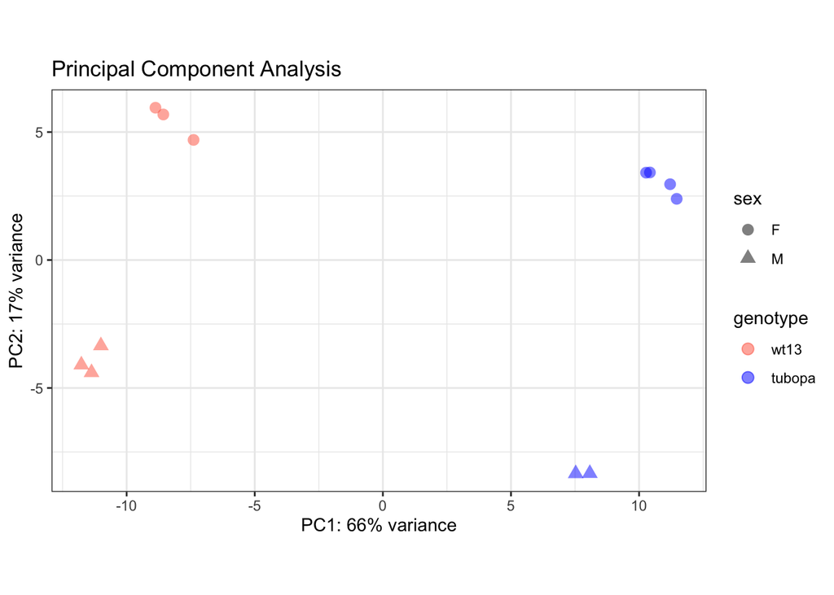

```r
# here I make a table with the values to plot along with the metadata so that it is easy to pass to ggplot.
prTab = data.frame(pca$x, tcoldata)

prTab %>%
  ggplot(aes(PC1, PC2, color = genotype, shape = sex)) +
  geom_point(size = 3, alpha = 0.5) +
  xlab(paste0("PC1: ", percentVar[1], "% variance")) + ylab(paste0("PC2: ", percentVar[2], "% variance")) +
  scale_color_manual(values = c("tomato", "blue")) + theme(axis.line = element_line(color = "black")) +
  theme_bw() +
  coord_fixed() +
  labs(title = 'Principal Component Analysis')
```

This is close, but not exactly identical to what we got with the DESeq approach. Note however that the sign of the principal components are meaningless.

With the output of `prcomp`, we can visualize the fraction of variance captured by all of the calculated principal components.

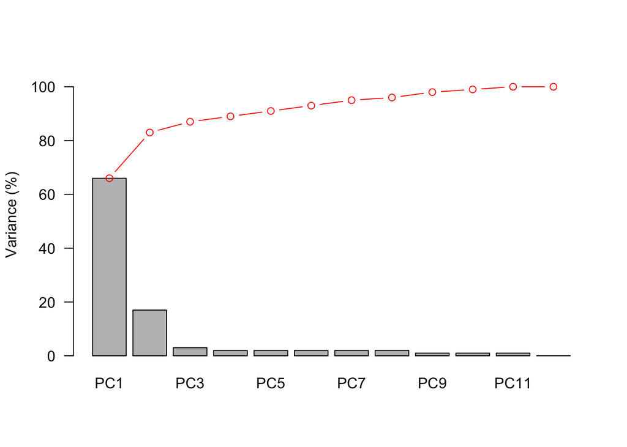

```r
b = barplot(percentVar, horiz = FALSE, las = 1, ylab = 'Variance (%)', ylim = c(0,105))
lines(b, cumuVar, type = 'b', col = 'red')
```

Bars show the percent of variance captured by each principal component. The red line shows the cumulative variance.

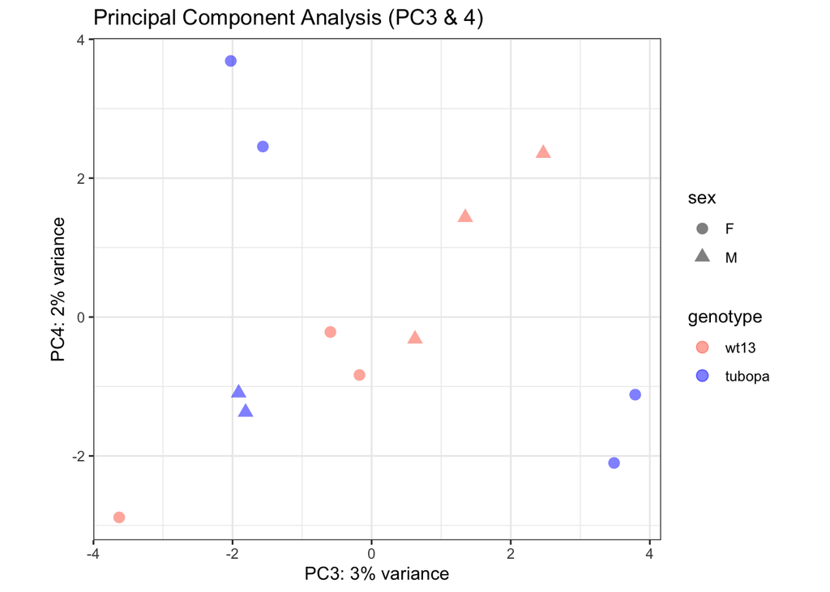

```r
prTab %>%
  ggplot(aes(PC3, PC4, color = genotype, shape = sex)) +
  geom_point(size = 3, alpha = 0.5) +
  xlab(paste0("PC3: ", percentVar[3], "% variance")) + ylab(paste0("PC4: ", percentVar[4], "% variance")) +
  scale_color_manual(values = c("tomato", "blue")) + theme(axis.line = element_line(color = "black")) +
  theme_bw() +
  coord_fixed() +
  labs(title = 'Principal Component Analysis (PC3 & 4)')
```

I have some hunches. The data were generated over two days (as encoded in the serial numbers for the samples). I did seven samples on one day and five on the other. *(aside: this is the point where I go back to the chunk where I generated the object `tcoldata` and add a column for `prepDate`. I then re-run all of this to get back to this point with the new `tcoldata` object.)*

We can test whether PC3 distinguishes samples on the basis of ‘prepDate’…

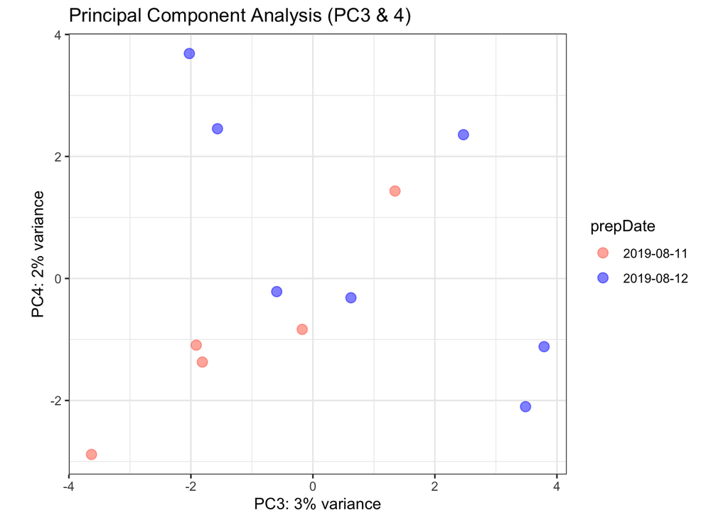

```r
prTab %>%
  ggplot(aes(PC3, PC4, color = prepDate)) +
  geom_point(size = 3, alpha = 0.5) +
  xlab(paste0("PC3: ", percentVar[3], "% variance")) + ylab(paste0("PC4: ", percentVar[4], "% variance")) +
  scale_color_manual(values = c("tomato", "blue")) + theme(axis.line = element_line(color = "black")) +
  theme_bw() +
  coord_fixed() +
  labs(title = 'Principal Component Analysis (PC3 & 4)')
```

Prep date does not explain either PC3 or PC4. I’ve looked over all the metadata for these libraries and nothing seems to explain either of these principal components.

Do we need to care about these? There are several criteria that can be applied to decide how many principal components to retain. One is the “80% rule” where you just keep the ones that explain greater than 80% of the variance, but this is obviously not a very rigorous cutoff. Another is more mathematically subtle, which begins with calculating the eigenvalues of the dataset.

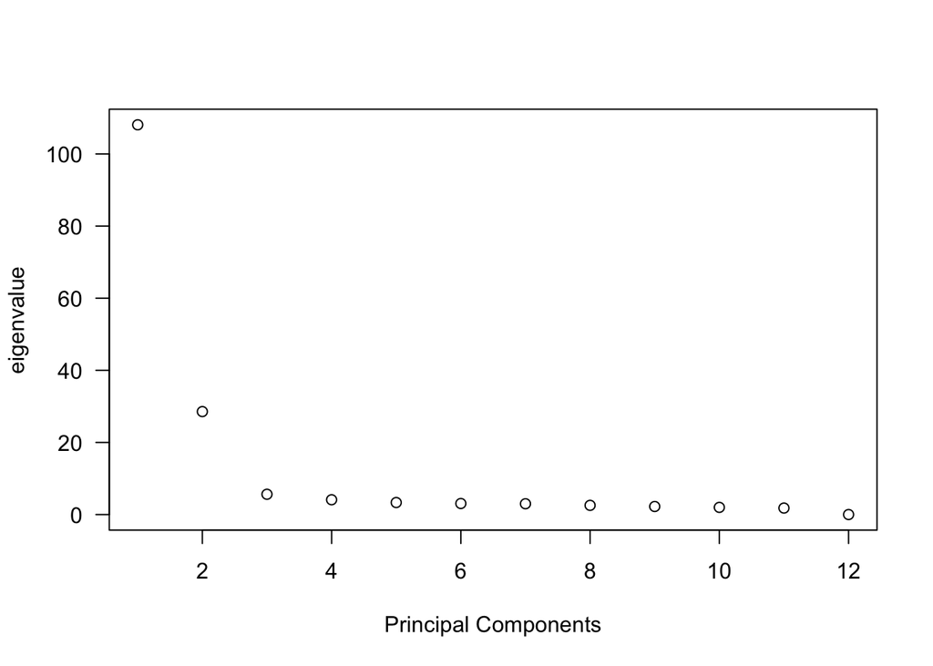

```r
eigenvalues = pca$sdev^2

plot(c(1:12), eigenvalues, xlab = 'Principal Components', ylab = 'eigenvalue', las = 1)
```

The eigenvalues are proportional to the square of the ‘standard deviation’ output of `prcomp`. The “Kaiser-Guttman” criterion for retaining principal components states that you only keep the ones whose eigenvalues are greater than the average eigenvalue.

```r
which(eigenvalues > mean(eigenvalues))
```

```
## [1] 1 2
```

By this criterion, (and the 80% rule), we only need to consider PC1 and PC2 for this particular dataset.

# PCA on the whole dataset.

I limited the analysis above to the top 1000 most variable regions because I expect around this many regions to have significant differences in the dataset. The ‘less variable’ regions are variable for reasons that likely reflect additional biological and technical influences that we are less interested in. Let’s do this on the whole dataset (not filtering by 1000 most variable peaks), and see how this affects our conclusions from above:

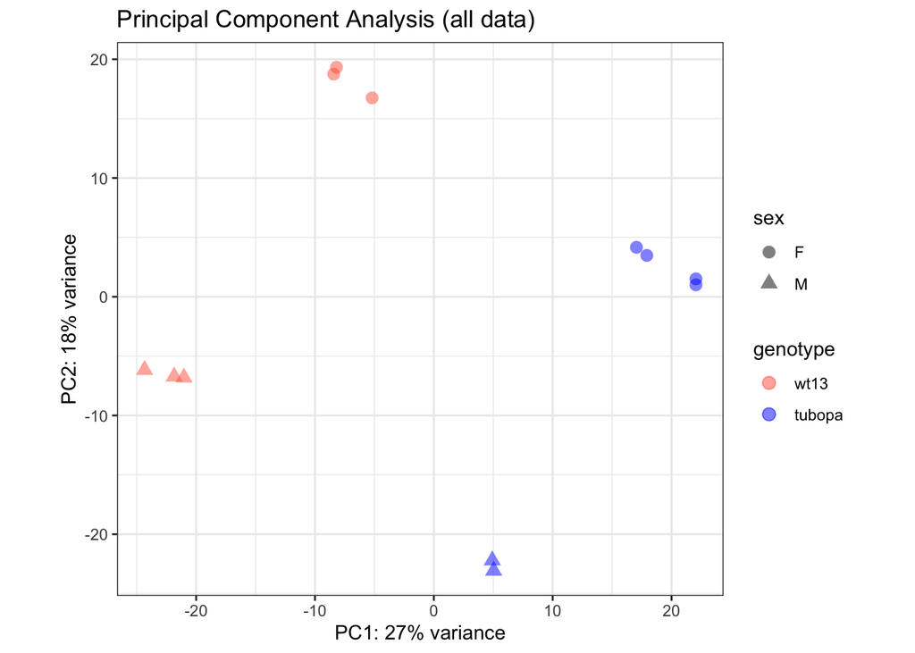

```r
pca2 = prcomp(t(scaled)) # only difference is that we don't filter. Otherwise the same data.

percentVar2 = round(100 * summary(pca2)$importance[2,])
cumuVar2 = round(100 * summary(pca2)$importance[3,])

prTab2 = data.frame(pca2$x, tcoldata)

prTab2 %>%
  ggplot(aes(PC1, PC2, color = genotype, shape = sex)) +
  geom_point(size = 3, alpha = 0.5) +
  xlab(paste0("PC1: ", percentVar2[1], "% variance")) + ylab(paste0("PC2: ", percentVar2[2], "% variance")) +
  scale_color_manual(values = c("tomato", "blue")) + theme(axis.line = element_line(color = "black")) +
  theme_bw() +
  coord_fixed() +
  labs(title = 'Principal Component Analysis (all data)')
```

A ha. Our principal components still distinguish genotype and sex, but these components explain a smaller overall fraction of the variance. (just 45%). Let’s look at our barplot again:

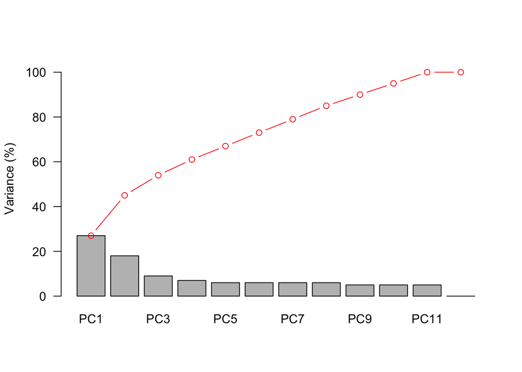

```r
b = barplot(percentVar2, horiz = FALSE, las = 1, ylab = 'Variance (%)', ylim = c(0,105))
lines(b, cumuVar2, type = 'b', col = 'red')
```

Definitely murkier. What does our statistical test tell us to retain?

```r
eigenvalues2 = pca2$sdev^2

which(eigenvalues2 > mean(eigenvalues2))
```

```
## [1] 1 2 3
```

Despite this, our test now tells us to heed the third principal component as well. Let’s have a look at PC3…

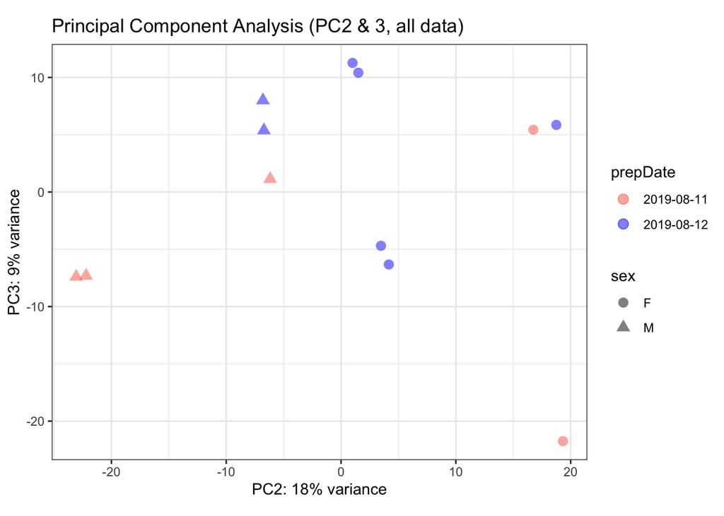

```r
prTab2 %>%
  ggplot(aes(PC2, PC3, color = prepDate, shape = sex)) +
  geom_point(size = 3, alpha = 0.5) +
  xlab(paste0("PC2: ", percentVar2[2], "% variance")) + ylab(paste0("PC3: ", percentVar2[3], "% variance")) +
  scale_color_manual(values = c("tomato", "blue")) + theme(axis.line = element_line(color = "black")) +
  theme_bw() +
  coord_fixed() +
  labs(title = 'Principal Component Analysis (PC2 & 3, all data)')
```

Again, we don’t have any immediate thoughts about what the biological or technical explanations are for this principal component.

If we wanted to account for this source of variance in the model formula for DESeq2 analysis, we could determine groups on the basis of whether the value for PC3 is positive or negative, and include this in the design formula. We would have to add this to the object `tcoldata`.

```r
tcoldata = cbind(tcoldata, PC3 = prTab2$PC3)

tcoldata
```

```
##                 sample.name genotype sex   prepDate        PC3
## 19081101_wt13      19081101     wt13   F 2019-08-11 -21.749685
## 19081102_wt13      19081102     wt13   F 2019-08-11   5.431422
## 19081103_wt13      19081103     wt13   M 2019-08-11   1.132749
## 19081206_wt13      19081206     wt13   M 2019-08-12   8.001671
## 19081207_wt13      19081207     wt13   M 2019-08-12   5.382983
## 19081208_wt13      19081208     wt13   F 2019-08-12   5.853673
## 19081104_tubopa    19081104   tubopa   M 2019-08-11  -7.395880
## 19081105_tubopa    19081105   tubopa   M 2019-08-11  -7.309675
## 19081201_tubopa    19081201   tubopa   F 2019-08-12  -4.695667
## 19081202_tubopa    19081202   tubopa   F 2019-08-12  -6.328281
## 19081204_tubopa    19081204   tubopa   F 2019-08-12  11.265666
## 19081205_tubopa    19081205   tubopa   F 2019-08-12  10.411024
```

Then we could do DESeq2:

```r
# initialize the DESeq dataset and process it:

tubdds = DESeqDataSetFromMatrix(countData = tubcounts, colData = tcoldata, design = ~ PC3 + sex + genotype)
```

```
##   the design formula contains one or more numeric variables that have mean or
##   standard deviation larger than 5 (an arbitrary threshold to trigger this message).
##   Including numeric variables with large mean can induce collinearity with the intercept.
##   Users should center and scale numeric variables in the design to improve GLM convergence.
```

```r
# now we perform DESeq
tubdds = DESeq(tubdds, parallel = FALSE)
resultsNames(tubdds)  # check the output of the comparisons made based on the design above.
```

```
## [1] "Intercept"               "PC3"
## [3] "sex_M_vs_F"              "genotype_tubopa_vs_wt13"
```

```r
res.tub = results(tubdds, contrast = c("genotype", "tubopa", "wt13"), independentFiltering = FALSE)
res.tub = as.data.frame(res.tub)
```

We can now visualize how this affects our differential analysis:

MA Plot:

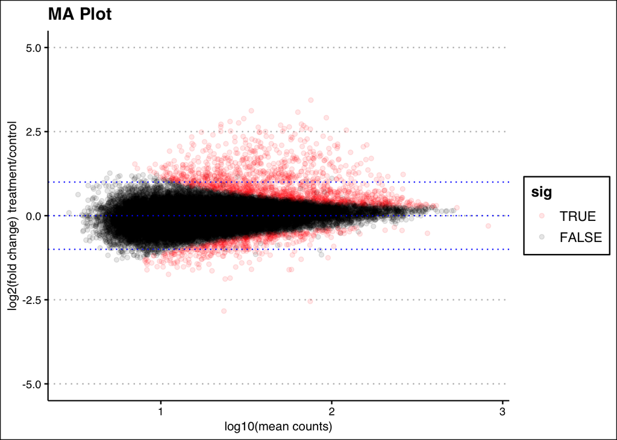

```r
res.tub %>%
  mutate(sig = padj < 0.05) %>%
  ggplot(aes(x = log10(baseMean), y = log2FoldChange, color = sig)) +
  geom_point(alpha = 0.1) +
  coord_cartesian(ylim = c(-5,5)) +
  scale_color_manual(values = c("TRUE" = "red", "FALSE" =  "black")) +
  geom_hline(yintercept = c(0,1,-1), linetype = 'dotted', color = 'blue') +
  theme_clean() +
  labs(title = "MA Plot",
       x = "log10(mean counts)",
       y = "log2(fold change) treatment/control")
```

Volcano:

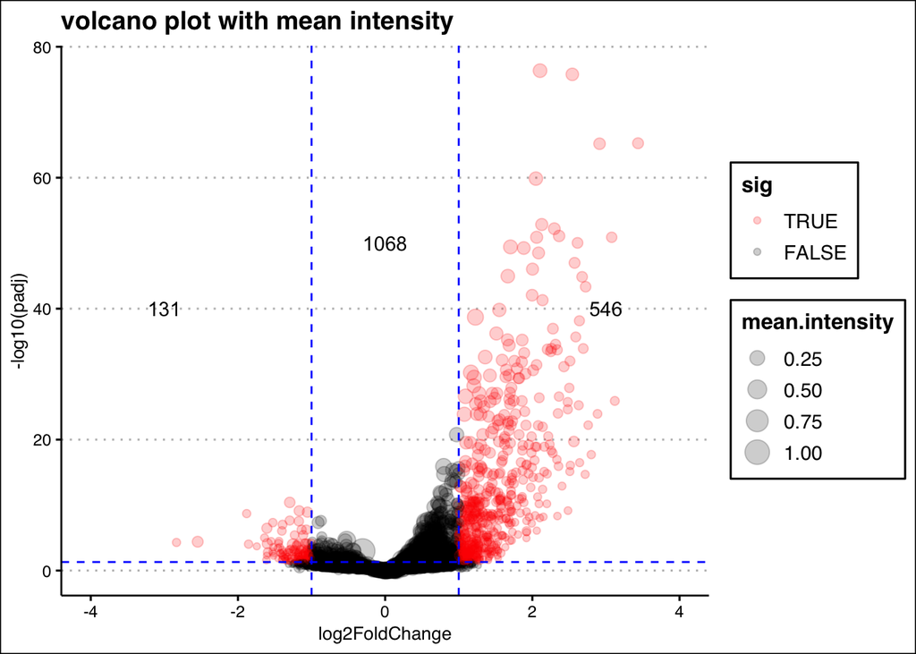

```r
supervolcano = res.tub %>%
  mutate(sig = padj <= 0.05 & abs(log2FoldChange) >= 1) %>%
  mutate(mean.intensity = baseMean/max(baseMean)) %>%
  ggplot(aes(x = log2FoldChange, y = -log10(padj), color = sig, size = mean.intensity)) +
  geom_point(alpha = 0.2) +
  coord_cartesian(xlim =c(-4,4)) +
  geom_hline(yintercept = -log10(0.05), linetype = 'dashed', col = 'blue') +
  geom_vline(xintercept = log2(c(0.5,2)), linetype = 'dashed', col = 'blue') +
  scale_color_manual(values = c("TRUE" = 'red', "FALSE" = "black")) +
  theme_clean() +
  labs(title = 'volcano plot with mean intensity')

supervolcano+
  annotate(geom = "text", x = -3, y = 40, label = length(which(res.tub$padj <= 0.05 & res.tub$log2FoldChange <= -1))) +
  annotate(geom = "text", x = 3, y = 40, label = length(which(res.tub$padj <= 0.05 & res.tub$log2FoldChange >= 1))) +
  annotate(geom = 'text', x = 0, y = 50, label = length(which(res.tub$padj <= 0.05 & abs(res.tub$log2FoldChange) < 1)))
```

Before when we didn’t consider the mysterious PC3, we had 136 ‘down’ peaks and ‘548’ up peaks. The middle was 1123 peaks. It appears, superficially, that including PC3 marginally affects the presumed true ‘up’ and ‘down’ peaks, and reduces substantially the ‘significant peaks with insufficient log2 fold change’. This appears to likely be an improvement in the analysis.